# Analyzing The Most Clutch NBA Player Today: Insert Bum Here

# 7 Star Low Sample size Issue

Table Showing Low Sample Size For Individual Stars vs. Many of Bums

```r
player_list %>%
  filter(Min == .5) %>%
  group_by(Player) %>%
  summarize(total = sum(tot_att))%>%
  arrange(desc(total))
```

```
## # A tibble: 14 x 2
##          Player total
##           <chr> <dbl>
##  1         Bums   156
##  2    K. Bryant    32
##  3     L. James    31
##  4    K. Durant    21
##  5  D. Nowitzki    19
##  6    T. Duncan    16
##  7 R. Westbrook    15
##  8     S. Curry    15
##  9   D. Lillard    14
## 10    J. Harden    14
## 11      D. Wade    13
## 12      D. Rose     9
## 13   K. Leonard     7
## 14    T. Parker     4
```

Create a pooled star group so comparison with bums is possible:

```r
player_list$Type <- if_else(player_list$Player %in% stars,"Stars", "Bums")

player_list %>%
  filter(Min == .5) %>%
  group_by(Type) %>%
  mutate(Percent = sum(tot_made) / sum(tot_att)) %>%
  summarise(Avr = mean(Percent))
```

```
## # A tibble: 2 x 2
##    Type       Avr
##   <chr>     <dbl>
## 1  Bums 0.4294872
## 2 Stars 0.3142857
```

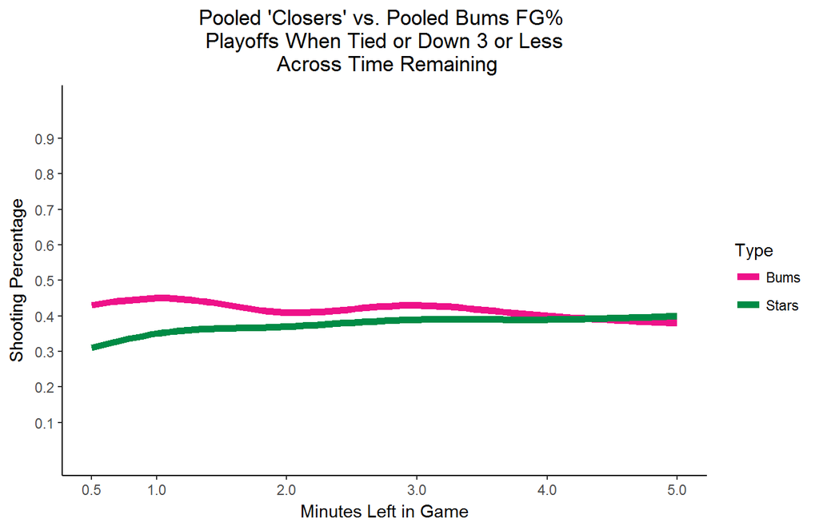

```r
#USE IN ARTICLE

bum_star_graph <- player_list %>%
  filter(Player != "Stars") %>%
  group_by(Type, Min) %>%
  summarize(tot_made = sum(tot_made), tot_att = sum(tot_att)) %>%
  mutate(Percentage = round(tot_made/tot_att,2)) %>%
  arrange(desc(Percentage))

ggplot(bum_star_graph, aes(Min, Percentage, color = Type))+
  geom_smooth(se = FALSE, size = 2)+
  scale_y_continuous(limits = c(0,1), breaks = c(.1,.2,.3,.4,.5,.6,.7,.8,.9))+
  scale_x_continuous(breaks = c(.5,1,2,3,4,5))+
  scale_color_manual(values = c("deeppink2","springgreen4"))+
  theme_classic()+
  ggtitle("Pooled 'Closers' vs. Pooled Bums FG% \n Playoffs When Tied or Down 3 or Less \n Across Time Remaining")+
  ylab("Shooting Percentage")+
  xlab("Minutes Left in Game")+
  theme(plot.title = element_text(hjust = 0.5))
```

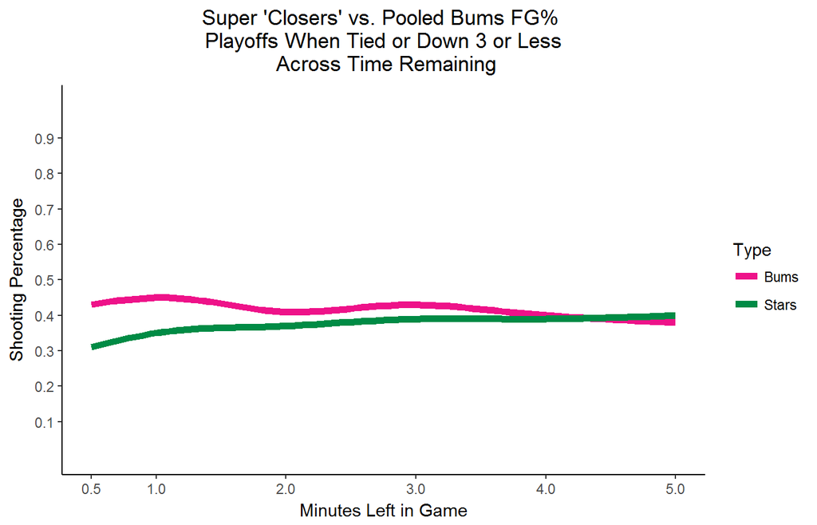

```r
super_stars <- c("S. Curry", "L. James", "K. Durant","K. Leonard", "D. Nowitzki","T. Duncan", "K. Bryant")

bum_star_graph <- player_list %>%
  filter(Player != "super_stars") %>%
  group_by(Type, Min) %>%
  summarize(tot_made = sum(tot_made), tot_att = sum(tot_att)) %>%
  mutate(Percentage = round(tot_made/tot_att,2)) %>%
  arrange(desc(Percentage))

ggplot(bum_star_graph, aes(Min, Percentage, color = Type))+
  geom_smooth(se = FALSE, size = 2)+
  scale_y_continuous(limits = c(0,1), breaks = c(.1,.2,.3,.4,.5,.6,.7,.8,.9))+
  scale_x_continuous(breaks = c(.5,1,2,3,4,5))+
  scale_color_manual(values = c("deeppink2","springgreen4"))+
  theme_classic()+
  ggtitle("Super 'Closers' vs. Pooled Bums FG% \n Playoffs When Tied or Down 3 or Less \n Across Time Remaining")+
  ylab("Shooting Percentage")+
  xlab("Minutes Left in Game")+
  theme(plot.title = element_text(hjust = 0.5))
```

Great plot. clearly shows that as minutes wane, clutch shooters (ACROSS THEIR CAREER) choke more than bums (IN LAST 6 YEARS) but with 5 min stars are better as expected.

# 8 Last Minutes Comparison (Stars vs. Bums)

Now go into last minute - show each and every second.

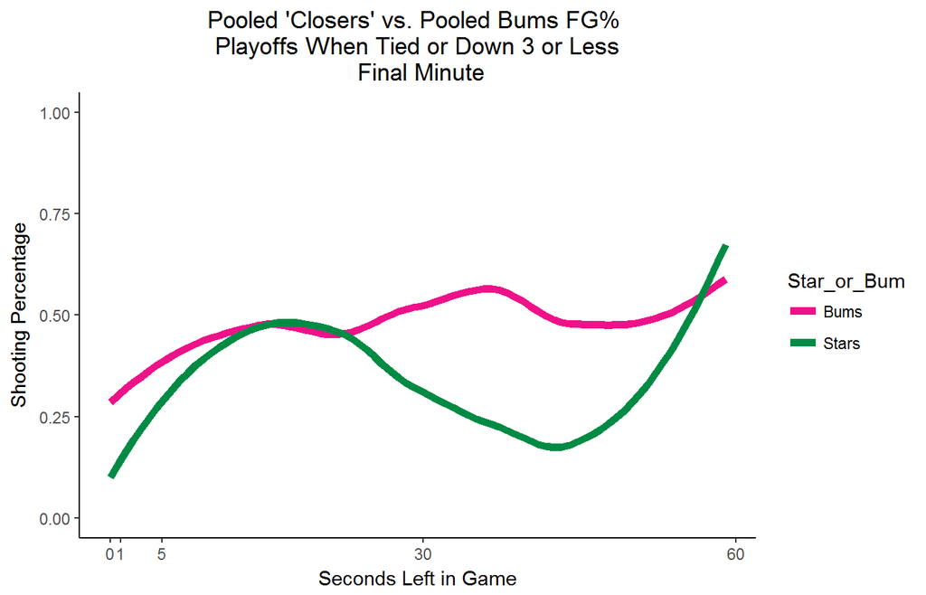

```r
clutch_analysis$Star_or_Bum <- NA
clutch_analysis$Star_or_Bum <- if_else(clutch_analysis$Player %in% stars,"Stars", "Bums")


last_min <- clutch_analysis %>%
  filter(Minutes == 0) %>%
  group_by(Star_or_Bum, Seconds) %>%
  summarize(tot_made = sum(Shot_Result), tot_att = n()) %>%
  mutate(Percentage = round(tot_made/tot_att,2))

ggplot(last_min, aes(Seconds, Percentage, fill = Star_or_Bum, color = Star_or_Bum))+
  geom_smooth(method = "loess", se = FALSE, size = 2)+
  scale_x_continuous(breaks = c(0,1,5,30,60))+
  scale_y_continuous(limits = c(0,1))+
  scale_color_manual(values = c("deeppink2","springgreen4"))+
  theme_classic()+
  ggtitle("Pooled 'Closers' vs. Pooled Bums FG% \n Playoffs When Tied or Down 3 or Less \n Final Minute")+
  ylab("Shooting Percentage")+
  xlab("Seconds Left in Game")+
  theme(plot.title = element_text(hjust = 0.5))
```